# Tematika és próbafeladatok

Tematika és próbafeladatok Matalapok  
Abari Kálmán 2021-09-11

## 1. témakör

- statisztika fogalma, ágai
- populáció és minta fogalma
- adatminta és változó fogalma
- mérés, mérési skálák
- diszkrét és folytonos változók
- a mintabeli eloszlás fogalma
- leíró statisztika
  - gyakorisági eloszlás (kategorikus, nem csoportosított, csoportosított), abszolút, relatív, százalékos, kumulatív
  - oszlopdiagram, pontdiagram, hisztogram
  - középértékek: átlag, medián, módusz
  - szóródási mutatók: terjedelem, IQR, kvantilisek, középeltérés, MAD, szórás, variancia, relatív szórás
  - alakmutatók: ferdeség és csúcsosság

## 2. témakör

- valószínűség-számítás, alapfogalmak, eseményalgebra
- valószínűség fogalma, valószínűségi mező, klasszikus valószínűségi mező
- feltételes valószínűség fogalma
- teljes valószínűség tétele, Bayes tétele
- események függetlensége
- valószínűségi változók fogalma, folytonos és diszkrét
- valószínűségi változó eloszlása
- várható érték, szórás és variancia
- eloszlásfüggvény és sűrűségfüggvény
- nevezetes eloszlások: normális, binomiális
- központi határeloszlás tétel

## 3. témakör

- induktív statisztika részei
- becsléselmélet (pont- és intervallumbecslés a várható értékre és szórásra)
- hipotézisvizsgálat fogalma, lépései
- az első- és másodfajú hiba
- a p-érték fogalma
- egymintás u-próba
- egymintás t-próba

## Feladatok az 1. témakörhöz (a megoldás dőlten szedve)

1. Határozza meg a következő statisztikai változók skálatípusát:
   - hajszín: *nominális*
   - iskolai végzettség: *ordinális*
   - IQ: *intervallum*
   - testmagasság cm-ben mérve: *arány*
   - testmagasság m-ben mérve: *arány*
   - hőmérséklet Celsius fokban mérve: *intervallum*
   - hőmérséklet Kelvinben mérve: *arány*
   - családi állapot: *nominális*.
2. Milyen ábrákat javasolna az előző feladatban szereplő változók eloszlásának szemléltetésére. *Nominális, ordinális: oszlopdiagram; intervallum, arány: hisztrogram vagy pontdiagram*.
3. Milyen esetben használjuk a `cut()` függvényt az R-ben. Adjon rá egy példát! *Például numerikus változók értékeinek csoportosítására. Testmagasságok csoportosítása.*
4. Tekintsük a következő mintát:

```
girl girl boy boy boy girl girl boy boy boy boy boy girl girl boy
girl girl boy boy boy boy girl girl girl girl boy boy boy girl boy
girl boy boy boy boy boy girl boy boy boy boy girl girl girl
```

```
a. Készítsünk gyakorisági táblázatot, százalékos gyakorisági táblázatot, és kummulált százalékos gyakorisági táblázatot! Írjuk le az R parancso(ka)t is!
```

```r
x <- factor(c("girl","girl","boy", "boy", "boy", "girl","girl","boy", "boy",
"boy", "boy", "boy", "girl","girl","boy","girl","girl","boy", "boy", "boy",
"boy", "girl","girl","girl","girl","boy", "boy", "boy", "girl","boy",
"girl","boy", "boy", "boy", "boy", "boy", "girl","boy", "boy", "boy", "boy",
"girl","girl","girl"))
table(x)
```

```
## x
##  boy girl
##   26   18
```

```r
prop.table(table(x))
```

```
## x
##       boy      girl
## 0.5909091 0.4090909
```

```r
cumsum(prop.table(table(x)))
```

```
##       boy      girl
## 0.5909091 1.0000000
```

```
b. Rajzoljuk meg a gyakorisági táblázathoz tartozó oszlopdiagram vázlatát (kézzel, hozzávetőleg)! Írjuk le az R parancso(ka)t is!
```

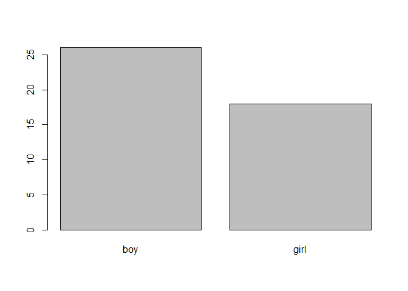

```r
barplot(table(x))
```

## Feladatok a 2. témakörhöz (a megoldás dőlten szedve, vagy külön jelezve)

1. 15 db villanykörtéből, amelyek között 5 hibás található, 3-at választunk ki találomra. Mi a valószínűsége, hogy
   1. egyik sem hibás  
      *Összes eset: R: `choose(15,3)`; Kedvező eset: `choose(10,3)` $P_a=120/455=0,26$*
   2. pontosan egy hibás  
      *Kedvező eset: $5\times\binom{10}{2}=225. P_b=225/455=0,49$*
   3. legalább egy hibás  
      *$P_c=1-P_a=0,74$*
2. A dohányosok (a felnőtt lakosság 40 %-a) az esetek 70 százalékában rendszeres feketekávézók is egyben, míg a nem dohányzóknak csak a 30 százaléka teszi ugyanezt. Ha kiválasztunk véletlenszerűen egy felnőttet, akkor mi a valószínűsége, hogy az illető rendszeres feketekávézó? Tegyük fel, hogy a kiválasztott személy rendszeres kávézó! Mi a valószínűsége, hogy egyben dohányos is?  
   *D – a véletlenül választott személy dohányos*  
   *ND – a véletlenül választott személy nem dohányos*  
   *K – a véletlenül választott személy feketekávézó*  
   *P(D)=0,4, P(ND)=0,6, P(K|D)=0,7, P(K|ND)=0,3*  
   *P(K)=?, P(D|K)=?*  
   *P(K)=P(D)P(K|D)+P(ND)P(K|ND)=0,4x0.7 + 0,6x0,3 = 0,46*  
   *P(D|K)=P(DK)/P(K)=(P(K|D)P(D))/P(K)=0,7x0,4/0,46=0,608*
3. Legyen 100 elemű minták esetén az $X$ átlagának szórása 3! Mennyi $X$ szórása? *30*
4. Legyen $X$ standard normális eloszlású valószínűségi változó. Határozzuk meg a következő valószínűségeket:
   1. $P(-0.73 < X < 0)$  
      *Megoldás kézi számolással, táblázatból: $F(0)-F(-0,73)=0,5–(1-F(0,73))=0,5-1+0,7673=0,2673$*  
      *Megoldás R-ben: `pnorm(0, mean=0, sd=1) - pnorm(-0.73, mean=0, sd=1)`*
   2. $P(-2 < X )$  
      *Megoldás kézi számolással, táblázatból: $P(X<2)=F(2)=0,9772*  
      *Megoldás R-ben: `pnorm(2, mean=0, sd=1)`*
5. Tegyük fel, hogy a Többváltozós statisztika kurzus vizsgaeredményei normális eloszlásúak, 85 pont várható értékkel és 15 pont szórással. Mi a valószínűsége, hogy egy véletlenül kiválasztott dolgozat
   1. 78 pontnál jobb *Megoldás kézi számolással, táblázatból: $P(X>78)=P(Z>(78-85)/15)=P(Z>-0,4666)= P(Z<0,4666) =F(0,4666) = 0,6796$*  
      *Megoldás R-ben: `1-pnorm(78, mean=85, sd=15)`*
   2. 75 és 85 pont közé esik  
      *Megoldás kézi számolással, táblázatból: $P(75<X<85)=P((75-85)/15<Z<(85-85)/15)= P(-0,6666<Z<0)=F(0)-F(-0,6666)=F(0)-(1-F(0,6666))= 0,2475$*  
      *Megoldás R-ben: `pnorm(85, mean=85, sd=15)-pnorm(75, mean=85, sd=15)`*
6. Az A csapat 2/3-os valószínűséggel nyer, ha játszik. Ha az A csapat 4 játékot játszik, akkor mennyi a valószínűsége, hogy
   1. pontosan 2 játékot nyer  
      *Megoldás R-ben: `dbinom(2, p=2/3, size=4)`*
   2. legalább egyet nyer  
      *Megoldás R-ben: `1-dbinom(0, p=2/3, size=4)`*
7. Valamely $Y$-nal jelölt valószínűségi változónak 4 különböző értéke lehetséges: -1, 1, 2, 3, s ezek rendre a következő valószínűséggel fordulnak elő: $P(-1)=0,4; P(1)=0,1; P(2)=0,1$.
   1. Határozzuk meg a hiányzó $P(3)$ valószínűséget.  
      *Megoldás: $P(3)=1-(P(-1)+P(1)+P(2))=0,4$*
   2. Határozzuk meg az $Y$ változó várható értékét és szórását!  
      $M(Y)=0,4\times(-1)+0,1\times1+0,1\times2+0,4\times3=1,1$  
      $D^2(Y)=((-1-1,1)\times2+(1-1,1)\times2+(2-1,1)\times2+(3-1,1)\times2)/4=2,21$  
      $D(Y)=1,486$
   3. A valószínűségi változó eloszlását ábrázoljuk vonaldiagramon!
   4. Rajzoljuk meg az $Y$ eloszlásfüggvényét is!

## Feladatok a 3. témakörhöz (a megoldás dőlten szedve, vagy külön jelezve)

1. A következő R output alapján válaszoljunk a kérdésekre:

```
##
##  One Sample t-test
##
## data:  c(12, 11, 14, 8, 14, 12, 8, 7, 9, 11, 12)
## t = 1, df = 10, p-value = 0.3409
## alternative hypothesis: true mean is not equal to 10
## 95 percent confidence interval:
##   9.106808 12.347737
## sample estimates:
## mean of x
##  10.72727
```

1. Melyik R függvényt használtuk a parancssorban? *`t.test()`*
2. Mi a nullhipotézise a fenti próbának? *H0: M(X)=10*
3. Mennyi a mintaelemszám? *n=11*
4. Szignifikáns a próba? *nem*
5. Mennyi a mintaátlag? *10.73*
6. Határozzuk meg a p értéket R paranccsal is. *`2*(1-pt(q=1, df=10))`*
2. Családok egy csoportjában vizsgálták az egy főre jutó havi nettó jövedelem értékét. Egy 5 elemű minta adatai a következőek (ezer Ft-ban): 20, 21, 23, 25, 26. Készítsünk pontbecslést a várható értékre és a varianciára. *(23; 6,5)*

```r
x <- c(20, 21, 23, 25, 26)   # minta rögzítése
mean(x)                      # mintaátlag
```

```
## [1] 23
```

```r
sd(x)                        # minta szórása
```

```
## [1] 2.54951
```

```r
var(x)                       # minta varianciája
```

```
## [1] 6.5
```

3. Családok egy csoportjában vizsgálták az egy főre jutó havi nettó jövedelem értékét. Egy 5 elemű minta adatai a következőek (ezer Ft-ban): 20, 21, 23, 25, 26. Készítsünk 95 %-os megbízhatóságú intervallum becslést a várható értékre, ha a populációbeli szórás 7. Határozzuk meg úgy is a 95 %-os megbízhatóságú intervallum határait, hogy a populációbeli szórás nem ismert. *(16,86; 29,14)*

```r
## Ismert szórás ----------------------------
# a minta
x <- c(20, 21, 23, 25, 26)

atlag.x <- mean(x) # átlag
alfa <- 0.05       # alfa
se.x <- qnorm(1-alfa/2)*7/sqrt(length(x)) # standard hiba

# az intervallum alsó határa
atlag.x-se.x
```

```
## [1] 16.86434
```

```r
# az intervallum felső határa
atlag.x+se.x
```

```
## [1] 29.13566
```

```r
## Ismeretlen szórás ----------------------------
# a minta
x <- c(20, 21, 23, 25, 26)
t.test(x)
```

```
##
##  One Sample t-test
##
## data:  x
## t = 20.172, df = 4, p-value = 3.565e-05
## alternative hypothesis: true mean is not equal to 0
## 95 percent confidence interval:
##  19.83437 26.16563
## sample estimates:
## mean of x
##        23
```

```r
atlag.x <- mean(x) # átlag
alfa <- 0.05       # alfa
s.x <- qt(p = 1-alfa/2, df = 4)*sd(x)/sqrt(length(x))

# az intervallum alsó határa
atlag.x-s.x
```

```
## [1] 19.83437
```

```r
# az intervallum felső határa
atlag.x+s.x
```

```
## [1] 26.16563
```

4. Azt állítjuk, hogy a négyfős családok átlagos költsége a baseball meccseken nem egyenlő 172 dollárral. Egy 22 elemű véletlen minta mintaátlaga 189,34 dollár lett. A minta szórása 33,65 dollár. Tegyük fel, hogy a változó normális eloszlású a populációban. Válaszoljuk meg, hogy az állításunk igaz vagy sem 10%-os szignifikancia szinten?  
   *$H_0:\mu=172$, t-próba, df=22-1=21, $\alpha$=0,10, $tkrit=\pm1,721$, t=2,42, mivel 2,42 nagyobb mint 1,721 ezért a $H_0$-t visszautasítjuk, azaz az állítást elfogadjuk.*

```r
mu <- 172          # nullhipotézisben szereplő konstans
n <- 22            # mintelemszám
atlag.x <- 189.34  # átlag
szoras.x <- 33.65  # minta szórása
alfa <- 0.1        # alfa

t.x <- (atlag.x-mu)/(szoras.x/sqrt(n)) # próbastatisztika értéke
t.x
```

```
## [1] 2.416993
```

```r
# 1. megoldás: hagyományos, a megtartási tartomány határaival
qt(p = alfa/2, df = n-1)   # alsó határ
```

```
## [1] -1.720743
```

```r
qt(p = 1-alfa/2, df = n-1) # felső határ
```

```
## [1] 1.720743
```

```r
# Mivel t.x nem esik a megtartási tartományba, ezért H1.

# 2. megoldás: p-érték alapján (kétoldali próbával)
(1-pt(q = t.x, df = n-1))*2
```

```
## [1] 0.02483266
```

```r
# Mivel p-érték kisebb, mint alfa, ezért H1.
```